# Tutorial 10 & 11, Lecture 11

Dawn Cheung

2024-04-28

# Tutorial 10 (Topic 8): k-means

the k-means algorithm finds out the distance among each element in your data, then find the number of centroids, allocate the element to the nearest centroids to form clusters, and the ultimate goal is to keep the size of each cluster as small as possible.

- note k is number of clusters / “groups”
- WSS: The sum distance within the centroids
  - small WSS => better model
- STANDARDISE THE INPUTS FOR K-means

```r
K = 15
wss <- numeric(K)

for (k in 1:K) {
   wss[k] <- sum(kmeans(scale(data[,c("floor_area_sqm","resale_price")]), centers=k)$withinss)
}


plot(1:K, wss, col = "blue", type="b", xlab="Number of Clusters",  ylab="Within Sum of Squares")
```

Suppose we have data for five objects on two features:

object x1 x2

```
 A  1   1
 B  1.5 2
 C  3   4
 D  3.5 5
 E  4.5 5
```

We set k = 2 to cluster the five data points into two clusters, P and Q, and initialize the algorithm with the centroids (x1,P , x2,P ) = (2, 2) and (x1,Q, x2,Q) = (4, 4).

1. Identify the objects in each cluster during the first iteration of the k-means algorithm

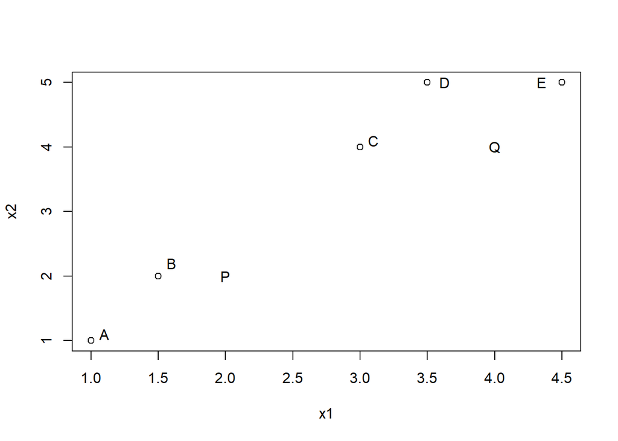

```r
##not possible to do via kmeans() => use plot() mnaually

x1 = c(1, 1.5, 3, 3.5, 4.5)
x2 = c(1, 2, 4, 5, 5)

objs = cbind(x1, x2)
plot(objs)

text(1.1, 1.1, "A")
text(1.6, 2.2, "B")
text(3.1, 4.1, "C")
text(3.63, 5, "D")
text(4.35, 5, "E")

text(2,2,"P")
text(4,4,"Q")
```

```r
###so now you can see quite clearly which points are nearer to which centroids

##tho u can also calculate using Euclidean distance
```

2. Compute the new centroids for the two clusters based on cluster assignment in (a).

```r
#P now has A and B
centriodP = c((1+1.5)/2, (1+2)/2)

#Q now has C, D, E
centriodQ = c((3+3.5+4.5)/3, (4+5+5)/3)

#im more or less literally doing averages btw

#but note that we're finding the MIDPOINT of all the points belonging to the different clusters

#and previous proposed centriods (not part of OG dataset) is removed / not considered

centriodP; centriodQ
```

```
## [1] 1.25 1.50
```

```
## [1] 3.666667 4.666667
```

3. Based on the centroids computed in (b), identify the objects in each cluster during the second iteration of the k-means algorithm.

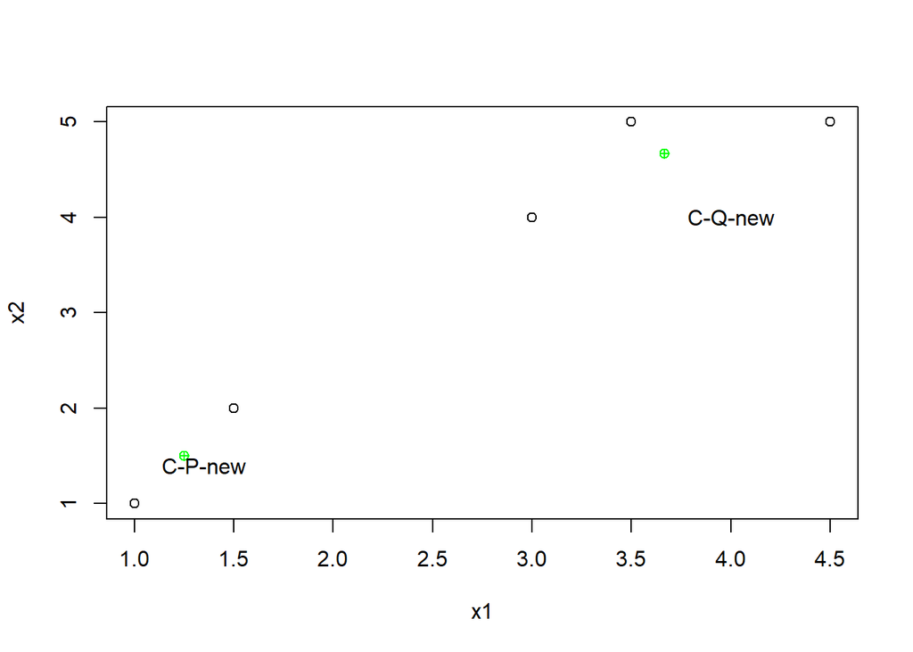

```r
plot(objs)

points(centriodP[1], centriodP[2], pch = 10, col = "green")
points(centriodQ[1], centriodQ[2], pch = 10, col = "green")

text(1.35, 1.4, "C-P-new")
text(4, 4, "C-Q-new")
```

note that since the points identified for the different clusters remains the same, the algorithm is converged! stable!

4. Calculate the Within Sum of Squares (WSS) for the clustering assignment in (c).

```r
data = data.frame(x1, x2)
data
```

```
##    x1 x2
## 1 1.0  1
## 2 1.5  2
## 3 3.0  4
## 4 3.5  5
## 5 4.5  5
```

```r
kout = kmeans(data, centers = 2)
kout
```

```
## K-means clustering with 2 clusters of sizes 2, 3
##
## Cluster means:
##         x1       x2
## 1 1.250000 1.500000
## 2 3.666667 4.666667
##
## Clustering vector:
## [1] 1 1 2 2 2
##
## Within cluster sum of squares by cluster:
## [1] 0.625000 1.833333
##  (between_SS / total_SS =  88.6 %)
##
## Available components:
##
## [1] "cluster"      "centers"      "totss"        "withinss"     "tot.withinss"
## [6] "betweenss"    "size"         "iter"         "ifault"
```

```r
kout$withinss
```

```
## [1] 0.625000 1.833333
```

```r
kout$tot.withinss #tbh idk what this one is doing
```

```
## [1] 2.458333
```

(K-Means) Consider data set hdb-2012-to-2014.csv which was extracted from the published data 1

The file has information on the HDB resale flats from Jan 2012 to Dec 2014.

1. Load data into R. Use k means algorithm to pick an optimal value for k in term of WSS, based on two variables, resale_price and floor_area_sqm.

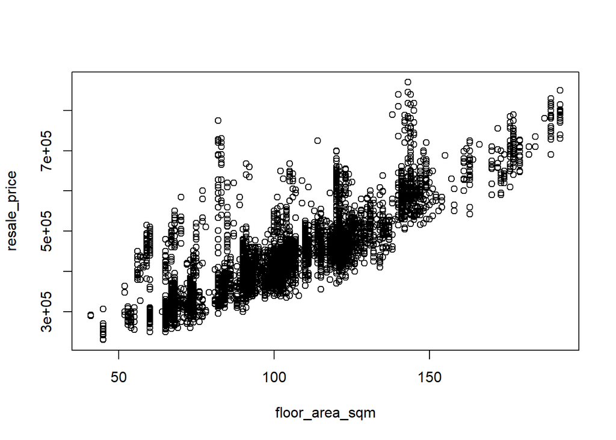

```r
sendhelp = read.csv("~/Github/DSA1101 Slayers/datasets/hdb-2012-to-2014.csv")
attach(sendhelp)

plot(floor_area_sqm, resale_price)#so we notice that the resale price is damnn high compared to the floor_area_sqm => MUST SCALE FEATURES
```

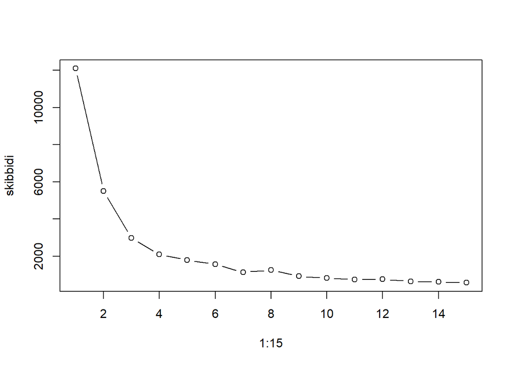

```r
skibbidi = c() #putting all the wss here

for (i in 1:15) {
  skibbidi[i] = sum(kmeans(scale(sendhelp[,c("floor_area_sqm","resale_price")]), centers=i)$withinss)
}
plot(1:15, skibbidi, type = "b")
```

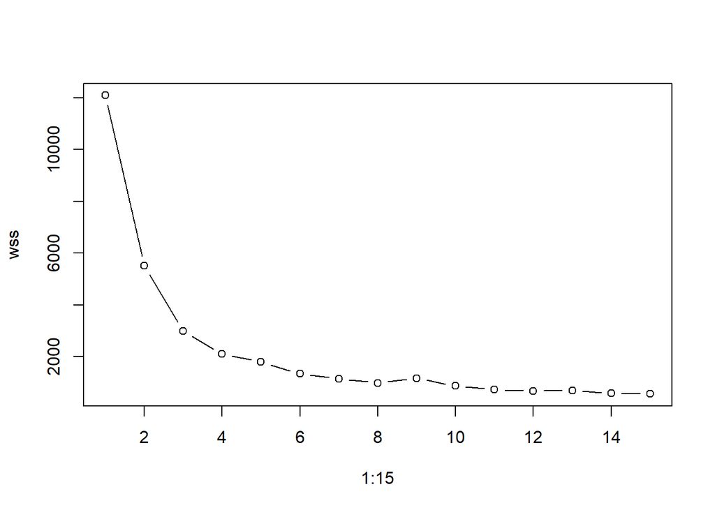

```r
kdata = scale(sendhelp[, c("floor_area_sqm","resale_price")])
wss = numeric(15)

for (i in 1:15) {
  wss[i] = sum(kmeans(kdata, centers = i)$withinss)
}

plot(1:15, wss, type = "b")
```

2. With the optimal k in part (a), plot the data points in the k clusters determined.

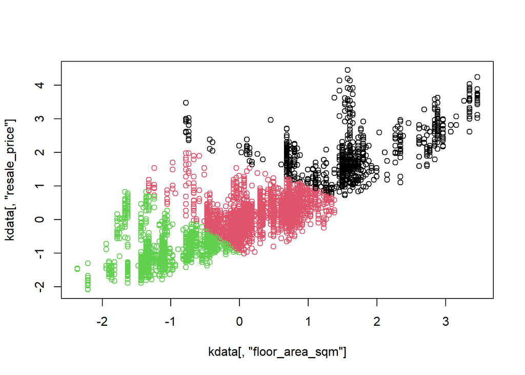

```r
kout = kmeans(kdata, centers = 3)

plot(kdata[, "floor_area_sqm"], kdata[, "resale_price"], col = kout$cluster)
```

# Tutorial 11 (Topic 9): association rules

A local retailer has a database that stores 10,000 transactions of last summer. After analyzing the data, a data science team has identified the following statistics:

- {battery} appears in 6000 transactions
- {sunscreen} appears in 5000 transactions
- {sandals} appears in 4000 transactions
- {bowls} appears in 2000 transactions
- {battery, sunscreen} appears in 1500 transactions
- {battery, sandals} appears in 1000 transactions
- {battery, bowls} appears in 250 transactions
- {battery, sunscreen, sandals} appears in 600 transactions
1. What are the support values of the preceding itemsets?

```r
sigh = c()

batsup = 6000 / 10000
sunsup = 5000 / 10000
sansup = 4000 / 10000
bowsup = 2000 / 10000
bat_sun_sup = 1500 / 10000
bat_san_sup = 1000 / 10000
bat_bow_sup = 250 / 10000
bat_sun_san_sup = 600 / 10000

sigh = c(batsup, sunsup, sansup, bowsup, bat_sun_sup, bat_san_sup, bat_bow_sup, bat_sun_san_sup)
```

2. Assuming the minimum support is 0.05, which itemsets are considered frequent?

```r
sigh[which(sigh > 0.05)] #then manually list the itemsets idk
```

```
## [1] 0.60 0.50 0.40 0.20 0.15 0.10 0.06
```

3. What are the confidence values of {battery} → {sunscreen} and {battery, sunscreen} → {sandals}? Which of these two rules is more interesting, i.e. has higher values of confidence?
2. Suppose for three products A, B and C, support({A}) = 0.6, support({B}) = 0.6, con dence({B} → {A}) = 0.9 and confidence({C} → {A, B}) = 0.5. Compute the following quantities.
1. Lift({A} → {B})
2. Leverage({A} → {B})
3. Confidence({A} → {B})
4. Lift({A, B} → {C})

# Lecture 11 (Topic 9)

```r
library("arules")
```

```r
library("arulesViz")
data(Groceries) #alr installed in R library arules; everyone can access it

#sparse matrix: specifically for association rules, stored in a dot and slash format
summary(Groceries)
```

```
## transactions as itemMatrix in sparse format with
##  9835 rows (elements/itemsets/transactions) and
##  169 columns (items) and a density of 0.02609146
##
## most frequent items:
##       whole milk other vegetables       rolls/buns             soda
##             2513             1903             1809             1715
##           yogurt          (Other)
##             1372            34055
##
## element (itemset/transaction) length distribution:
## sizes
##    1    2    3    4    5    6    7    8    9   10   11   12   13   14   15   16
## 2159 1643 1299 1005  855  645  545  438  350  246  182  117   78   77   55   46
##   17   18   19   20   21   22   23   24   26   27   28   29   32
##   29   14   14    9   11    4    6    1    1    1    1    3    1
##
##    Min. 1st Qu.  Median    Mean 3rd Qu.    Max.
##   1.000   2.000   3.000   4.409   6.000  32.000
##
## includes extended item information - examples:
##        labels  level2           level1
## 1 frankfurter sausage meat and sausage
## 2     sausage sausage meat and sausage
## 3  liver loaf sausage meat and sausage
```

```r
inspect(head(Groceries)) #inspect is under library arules
```

```
##     items
## [1] {citrus fruit,
##      semi-finished bread,
##      margarine,
##      ready soups}
## [2] {tropical fruit,
##      yogurt,
##      coffee}
## [3] {whole milk}
## [4] {pip fruit,
##      yogurt,
##      cream cheese ,
##      meat spreads}
## [5] {other vegetables,
##      whole milk,
##      condensed milk,
##      long life bakery product}
## [6] {whole milk,
##      butter,
##      yogurt,
##      rice,
##      abrasive cleaner}
```

```r
inspect(head(Groceries, 10)) #inspect first 10 itemsets instead of first 6
```

```
##      items
## [1]  {citrus fruit,
##       semi-finished bread,
##       margarine,
##       ready soups}
## [2]  {tropical fruit,
##       yogurt,
##       coffee}
## [3]  {whole milk}
## [4]  {pip fruit,
##       yogurt,
##       cream cheese ,
##       meat spreads}
## [5]  {other vegetables,
##       whole milk,
##       condensed milk,
##       long life bakery product}
## [6]  {whole milk,
##       butter,
##       yogurt,
##       rice,
##       abrasive cleaner}
## [7]  {rolls/buns}
## [8]  {other vegetables,
##       UHT-milk,
##       rolls/buns,
##       bottled beer,
##       liquor (appetizer)}
## [9]  {pot plants}
## [10] {whole milk,
##       cereals}
```

```r
Groceries@itemInfo[1:10,] #all columns
```

```
##               labels  level2           level1
## 1        frankfurter sausage meat and sausage
## 2            sausage sausage meat and sausage
## 3         liver loaf sausage meat and sausage
## 4                ham sausage meat and sausage
## 5               meat sausage meat and sausage
## 6  finished products sausage meat and sausage
## 7    organic sausage sausage meat and sausage
## 8            chicken poultry meat and sausage
## 9             turkey poultry meat and sausage
## 10              pork    pork meat and sausage
```

```r
Groceries@data[,100:105] #all rows
```

```
## 169 x 6 sparse Matrix of class "ngCMatrix"
##
##   [1,] . . . | . .
##   [2,] . . | . | .
##   [3,] . . . . . .
##   [4,] . . . . . .
##   [5,] . . . . . .
##   [6,] . . . . . .
##   [7,] . . . . . .
##   [8,] . . . . . .
##   [9,] . . . . . .
##  [10,] . . | . . .
##  [11,] . . . . . .
##  [12,] . . . . . .
##  [13,] . . . . . .
```

[output cut: 156 more lines]

```r
#sparse matrix: specifically for association rules, stored in a dot and slash format

#see the items for the first 5 transactions
apply(Groceries@data[,1:5], 2,
      function(r) paste(Groceries@itemInfo[r, "labels"], collapse = ", "))
```

```
## [1] "citrus fruit, semi-finished bread, margarine, ready soups"
## [2] "tropical fruit, yogurt, coffee"
## [3] "whole milk"
## [4] "pip fruit, yogurt, cream cheese , meat spreads"
## [5] "other vegetables, whole milk, condensed milk, long life bakery product"
```

```r
#2: 2nd column
#so this converts the sparse matrix into a readable itemset

#see the items for 100 to 105th transactions (index)
apply(Groceries@data[,100:105], 2,
      function(r) paste(Groceries@itemInfo[r, "labels"], collapse = ", "))
```

```
## [1] "citrus fruit, tropical fruit"
## [2] "soda, misc. beverages"
## [3] "sausage, pork, grapes, whole milk, rolls/buns, pastry, soda, specialty bar, bathroom cleaner"
## [4] "frankfurter, rolls/buns, bottled water"
## [5] "sausage, whole milk, yogurt, coffee, fruit/vegetable juice, bottled beer, softener, napkins, photo/film, shopping bags"
## [6] "soda"
```

```r
#get the frequent 1-itemset



itemset.1 = apriori(Groceries, parameter = list(minlen = 1, maxlen = 1, support = 0.04, target = "frequent itemsets"))
```

[output not shown]

```
##  done [0.00s].
## sorting transactions ... done [0.00s].
## writing ... [32 set(s)] done [0.00s].
## creating S4 object  ... done [0.00s].
```

```r
summary(itemset.1)
```

```
## set of 32 itemsets
##
## most frequent items:
## frankfurter     sausage     chicken        pork        beef     (Other)
##           1           1           1           1           1          27
##
## element (itemset/transaction) length distribution:sizes
##  1
## 32
##
##    Min. 1st Qu.  Median    Mean 3rd Qu.    Max.
##       1       1       1       1       1       1
##
## summary of quality measures:
##     support            count
##  Min.   :0.04209   Min.   : 414.0
##  1st Qu.:0.05709   1st Qu.: 561.5
##  Median :0.07397   Median : 727.5
##  Mean   :0.08909   Mean   : 876.2
##  3rd Qu.:0.10013   3rd Qu.: 984.8
##  Max.   :0.25552   Max.   :2513.0
##
## includes transaction ID lists: FALSE
##
## mining info:
##       data ntransactions support confidence
##  Groceries          9835    0.04          1
##                                                                                                               call
##  apriori(data = Groceries, parameter = list(minlen = 1, maxlen = 1, support = 0.04, target = "frequent itemsets"))
```

```r
inspect(sort(itemset.1, by = "support"))
```

```
##      items                   support    count
## [1]  {whole milk}            0.25551601 2513
## [2]  {other vegetables}      0.19349263 1903
## [3]  {rolls/buns}            0.18393493 1809
## [4]  {soda}                  0.17437722 1715
## [5]  {yogurt}                0.13950178 1372
## [6]  {bottled water}         0.11052364 1087
## [7]  {root vegetables}       0.10899847 1072
## [8]  {tropical fruit}        0.10493137 1032
## [9]  {shopping bags}         0.09852567  969
## [10] {sausage}               0.09395018  924
## [11] {pastry}                0.08896797  875
## [12] {citrus fruit}          0.08276563  814
## [13] {bottled beer}          0.08052872  792
## [14] {newspapers}            0.07981698  785
```

[output cut: 18 more lines]

```r
itemset.2 = apriori(Groceries, parameter = list(minlen = 2, maxlen = 2, support = 0.02, target = "frequent itemsets"))
```

[output not shown]

```
##  done [0.00s].
## sorting transactions ... done [0.00s].
## writing ... [61 set(s)] done [0.00s].
## creating S4 object  ... done [0.00s].
```

```r
summary(itemset.2)
```

```
## set of 61 itemsets
##
## most frequent items:
##       whole milk other vegetables           yogurt       rolls/buns
##               25               17                9                9
##             soda          (Other)
##                9               53
##
## element (itemset/transaction) length distribution:sizes
##  2
## 61
##
##    Min. 1st Qu.  Median    Mean 3rd Qu.    Max.
##       2       2       2       2       2       2
##
## summary of quality measures:
##     support            count
##  Min.   :0.02003   Min.   :197.0
##  1st Qu.:0.02227   1st Qu.:219.0
##  Median :0.02613   Median :257.0
##  Mean   :0.02951   Mean   :290.3
##  3rd Qu.:0.03223   3rd Qu.:317.0
##  Max.   :0.07483   Max.   :736.0
##
## includes transaction ID lists: FALSE
##
## mining info:
##       data ntransactions support confidence
##  Groceries          9835    0.02          1
##                                                                                                               call
##  apriori(data = Groceries, parameter = list(minlen = 2, maxlen = 2, support = 0.02, target = "frequent itemsets"))
```